# Reproducible Research: Peer Assessment 1

Emi Harry

June 8, 2016

```r
knitr::opts_chunk$set(echo = TRUE, tidy = FALSE, fig.show = 'asis', fig.width=8, fig.height=6, fig.align = 'center', fig.path = 'figure/', fig.lp = "Figure.", fig.keep = 'all')
```

## Section 1

### Loading and preprocessing the data

Read dataset into R

```r
fileurl <- "https://d396qusza40orc.cloudfront.net/repdata%2Fdata%2Factivity.zip"
temp <- tempfile()
download.file(fileurl, temp)
unzip(temp, list = T)
```

```
##           Name Length                Date
## 1 activity.csv 350829 2014-02-11 10:08:00
```

```r
dataset1 <- read.table(unzip(temp, "activity.csv"), header = T, sep = ",", stringsAsFactors = F)
unlink(temp)
```

## Section 2

Next, to find the total steps per day

- Load the data table package.
- Convert to data table and convert the data column variables to dates.
- Remove the NA’s

```r
library(data.table)
dt <- as.data.table(dataset1)
dt$date <- as.Date(dt$date)

# remove the NA's
dt2 <- na.omit(dt)
```

- Load the dply package and use it to group by date and create the subset.
- Summarise the steps each and save in a new dataset

```r
library(dplyr)
dtgroup <- group_by(dt2, date)
dtanalysis <- summarise(dtgroup, sum(steps))
```

Check the column names and reset it to apprioprate names

```r
names(dtanalysis)
```

```
## [1] "date"       "sum(steps)"
```

```r
setnames(dtanalysis, c("date", "sum(steps)"),
         c("date", "total_steps"))
```

Plot the histogram of the total daily steps

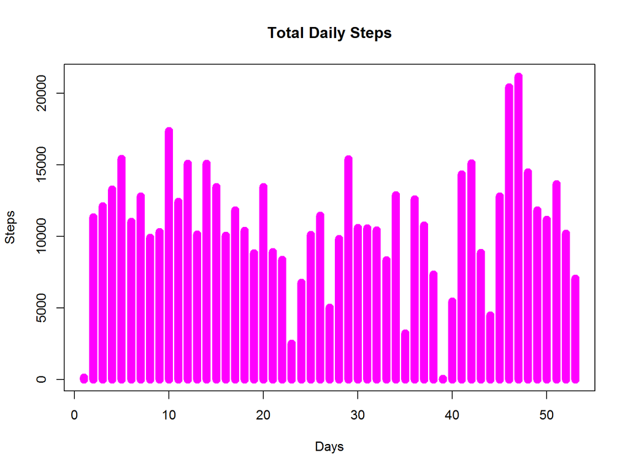

```r
plot(dtanalysis$total_steps, type = "h", lwd = 10,
     main = "Total Daily Steps", xlab = "Days", ylab = "Steps", col = 6)
```

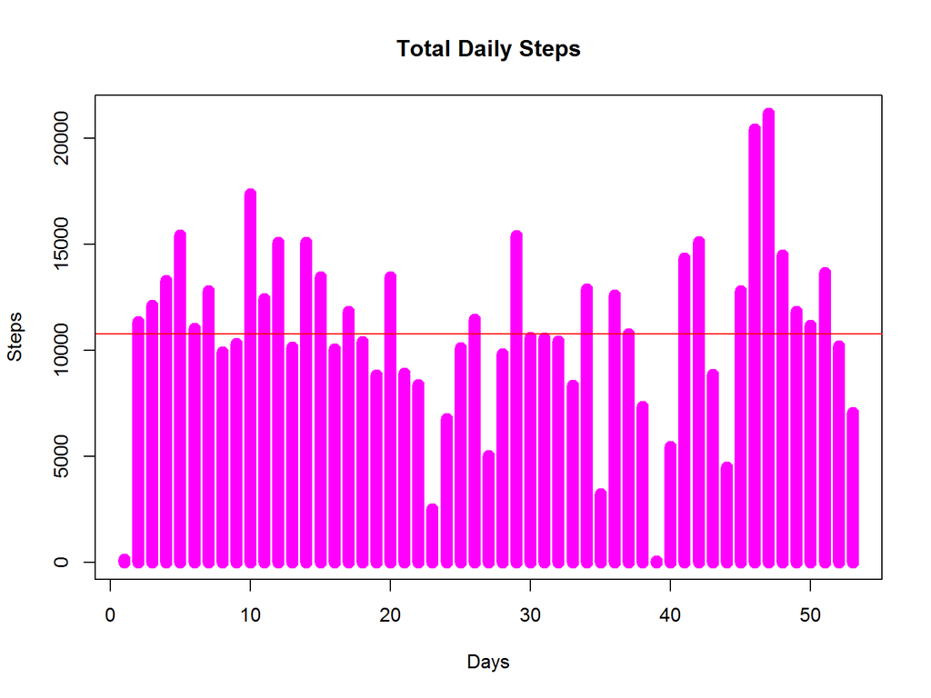

```r
abline(h = mean(dtanalysis$total_steps), col = 2)
```

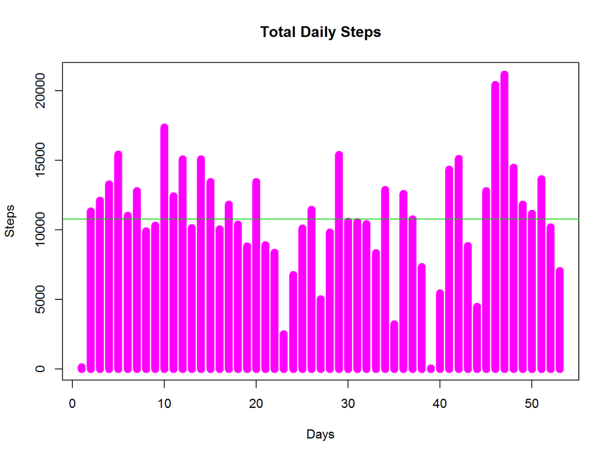

```r
abline(h = median(dtanalysis$total_steps), col = 3)
```

### What is mean total number of steps taken per day?

Finding the mean and median of steps derived from the total daily steps.

```r
firstmean <- mean(dtanalysis$total_steps)
firstmedian <- median(dtanalysis$total_steps)
```

The mean is 1.076618910^{4} and the median is 10765.

### Section 3

Group by time interval and find thier averages

```r
intvervalgroup <- group_by(dt2, interval)
dtinterval <- summarise(intvervalgroup, mean(steps))
```

### What is the average daily activity pattern?

Plot time series of average steps taken

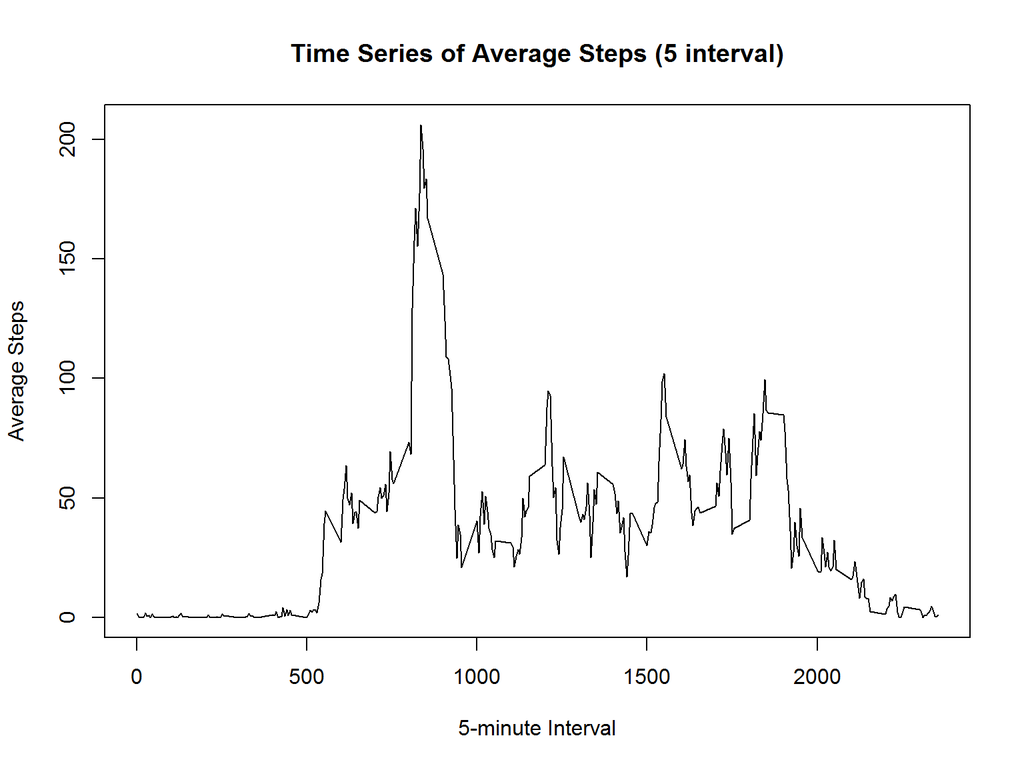

```r
plot(dtinterval$interval, dtinterval$`mean(steps)`, main = "Time Series of Average Steps (5 interval)",
     type = "l", xlab = "5-minute Interval", ylab = "Average Steps")
```

Set the interval as row names and get the corresponding value for the max mean

```r
df <- as.data.frame(dtinterval)
row.names(df) <- dtinterval$interval
maxindex <- which.max(dtinterval$`mean(steps)`)
max5 <- rownames(df)[maxindex]
```

The 5-minute interval with the highest average steps is 835.

## Section 4

### Imputing missing values

load the mice package and view the pattern of the missing data

```r
library(mice)
md.pattern(dataset1)
```

```
##       interval steps  date
## 15264        1     1     0     1
##  2304        1     0     0     2
##              0  2304 17568 19872
```

```r
library(VIM)
```

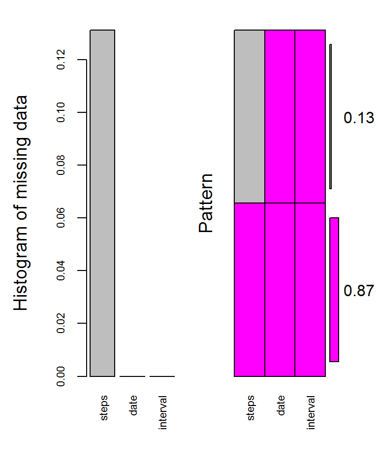

```
##
##  Variables sorted by number of missings:
##  Variable     Count
##     steps 0.1311475
##      date 0.0000000
##  interval 0.0000000
```

```r
aggr_plot <- aggr(dataset1, col=c('magenta','gray'), numbers=TRUE, sortVars=TRUE,
                  labels=names(dataset1), cex.axis=.7, gap=3,
                  ylab=c("Histogram of missing data","Pattern"))
```

use the predictive mean matching method in imputing the missing data

```r
tempData <- mice(dataset1,m=5,maxit=10,meth='pmm',seed=500)
summary(tempData)
```

```
## Multiply imputed data set
## Call:
## mice(data = dataset1, m = 5, method = "pmm", maxit = 10, seed = 500)
## Number of multiple imputations:  5
## Missing cells per column:
##    steps     date interval
##     2304        0        0
## Imputation methods:
##    steps     date interval
##    "pmm"    "pmm"    "pmm"
## VisitSequence:
## steps
##     1
## PredictorMatrix:
##          steps date interval
## steps        0    0        1
## date         0    0        0
## interval     0    0        0
## Random generator seed value:  500
```

```r
completedData <- complete(tempData,2)
```

To find the total steps per day, convert to data table and subset by date. Then sum the steps in each subset. Use the dplyr package to do the grouping.

```r
completedData <- as.data.table(completedData)
comp <- group_by(completedData, date)
ctotal <- summarise(comp, sum(steps))
cmean <- mean(ctotal$`sum(steps)`)
cmedian <- median(ctotal$`sum(steps)`)
```

After inputing the missing values, the new mean is 1.146654110^{4} and the median is 11458.

plot the histogram of the total daily steps after NA values are added.

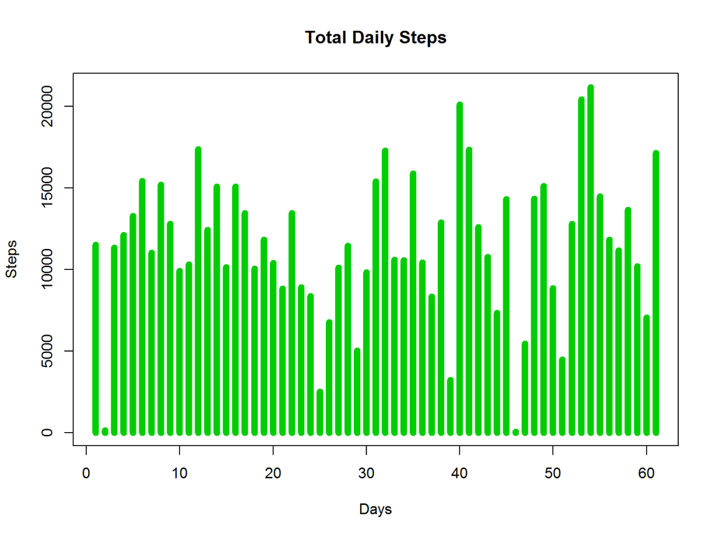

```r
plot(ctotal$`sum(steps)`, type = "h", lwd = 7,
     main = "Total Daily Steps", xlab = "Days", ylab = "Steps", col = 11)
```

## Section 5

View date as weekdays

```r
comp$date <- as.Date(comp$date)
comp$date <- weekdays(comp$date)
```

Create 2 subsets for weekday and weekend

```r
dtweekday <- comp[grep("Monday|Tuesday|Wednesday|Thursday|Friday", date, ignore.case =T)]
wkdy <- group_by(dtweekday, interval)
wkdymean <- summarise(wkdy, mean(steps))

dtweekend <- comp[grep("Saturday|Sunday", date, ignore.case = T)]
wknd <- group_by(dtweekend, interval)
wkndmean <- summarise(wknd, mean(steps))
```

Add the day_type column to both datasets

```r
wkdymean <- data.table(wkdymean, day_type = "weekday")
wkndmean <- data.table(wkndmean, day_type = "weekend")
```

Row bind the 2 datasets to creat a new factor variable in the dataset with two levels - “weekday” and “weekend”

```r
dtgroup3 <- rbind(wkdymean, wkndmean)
```

Use the weekday and weekend datasets to plot the graphs for 5-minute intervals

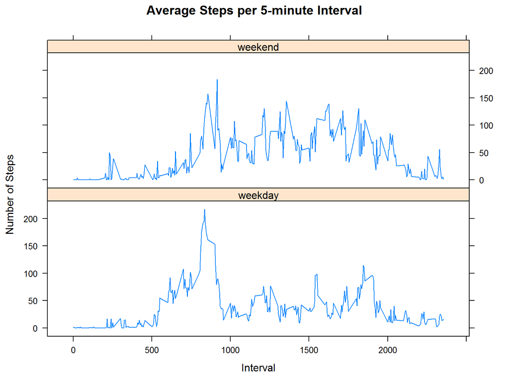

```r
library(lattice)
wk <- xyplot(dtgroup3$`mean(steps)` ~ dtgroup3$interval | factor(dtgroup3$day_type), type = "l", main = "Average Steps per 5-minute Interval", ylab = "Number of Steps", xlab = "Interval", layout = c(1,2))
print(wk)
```